# Publication-ready ggplot2

Scientific workflows: Tools and Tips 🛠️

2026-05-21

## What is this lecture series?

### Scientific workflows: Tools and Tips 🛠️

📅 Every 3rd Thursday 🕓 4-5 p.m. 📍 Webex

- One topic from the world of scientific workflows
- Material provided [online](https://selinazitrone.github.io/tools_and_tips/)
- If you don’t want to miss a lecture
  - [Subscribe to the mailing list](https://lists.fu-berlin.de/listinfo/toolsAndTips)
- For credit points: Send me a short message (Email or Webex)

## From default to publication-ready

- Making a first plot is easy, but making it publication-ready takes more work, choices and iterations

So many things you can tune:

- The plot itself: which geoms to pick
- Themes, colours, fonts
- How to highlight your results
- Creating multi-panel plots
- Exporting at a readable size

Different outputs (poster/talk/journal figure) require different tweaks

## Today

We’ll focus on:

1. **Custom themes** for a consistent look
2. **Colour** choice
3. **Multi-panel layouts**: how to combine plots
4. **Exporting** plots at the right size and resolution

**Note**

This is not an exhaustive list, there is so much more ggplot extension packages and tricks out there.

## How it works

- There’s a **GitHub repo** you download and open in your IDE (I’ll use Positron)
- I demonstrate each topic: **follow along or just watch**
- Each module has a short **exercise** to play with the concept
- **Questions** anytime: in the chat or just unmute

## Get set up

1. Click the green **Code** button → **Download ZIP**
2. Unzip it somewhere you can find it
3. Double-click the `.Rproj` file → opens in RStudio
   - *(Positron/VS code users: open the folder)*
4. Run `install_packages.R` to install today’s packages

Repo: https://github.com/selinaZitrone/advanced-ggplot-workshop

# 1. Custom themes

## The default isn’t publication-ready

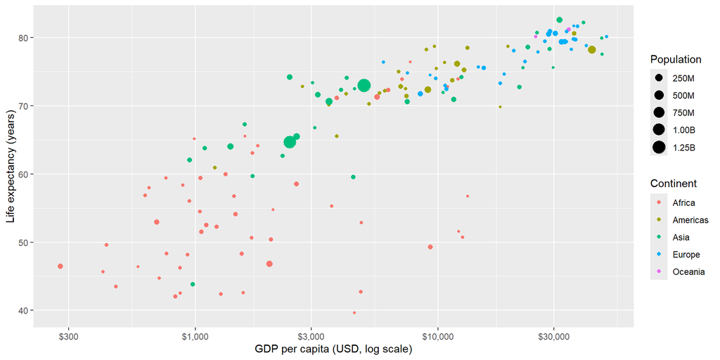

## Built-in themes: a quick win

Add a `theme_*()` layer and the whole look changes.

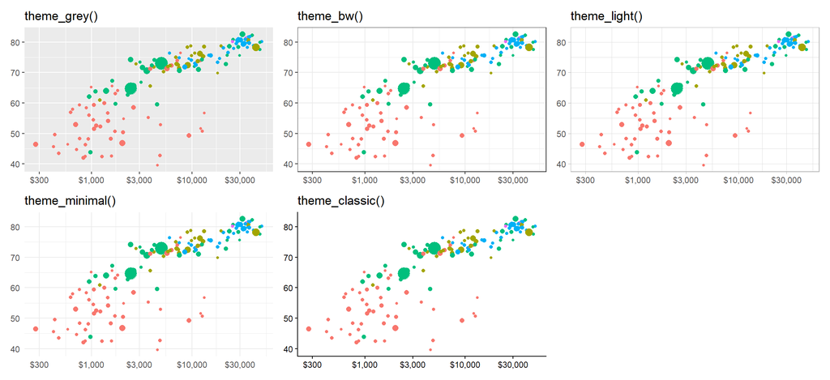

## Further customization with `theme()`

A theme controls everything that isn’t data: Fonts, sizes, colours, grid lines, spacing, legends, …

[figure not shown]

ggplot2 theme-system cheatsheet (by [Clara Granell](https://github.com/claragranell/ggplot2/tree/main))

## Inheritance of `theme` elements

```
text  ──┬── axis.text  ──┬── axis.text.x
        │                └── axis.text.y
        ├── plot.title
        ├── plot.subtitle
        └── legend.text

line  ──┬── axis.line   ──┬── axis.line.x
        │                 └── axis.line.y
        ├── axis.ticks
        └── panel.grid   ─── panel.grid.major / minor

rect  ──┬── plot.background
        └── panel.background
```

- Set a **parent** and it affects all its **children**
- E.g. Change `text` once and every piece of text updates

## How to change a theme

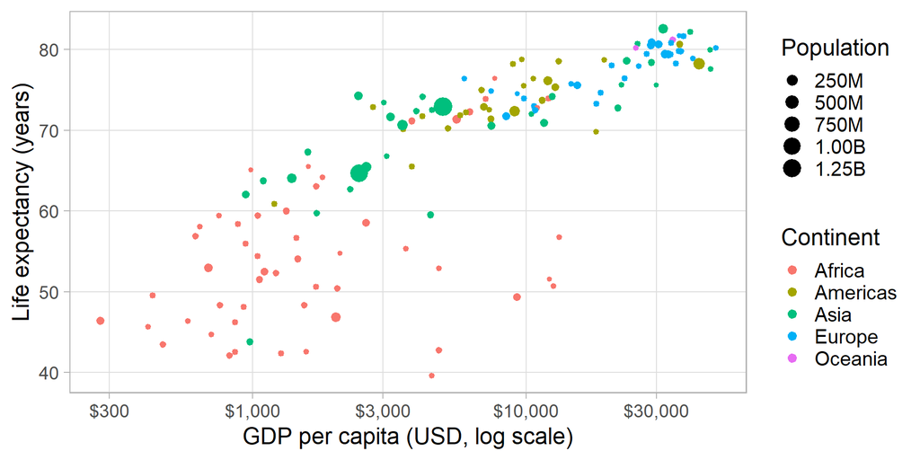

```r
p_bubble +
  theme_light(base_size = 18) +
  theme(
    legend.text = element_text(size = rel(0.85)),
    panel.grid.minor = element_blank()
  )
```

## Live demo

Open `demo/01_themes.R`

## Your turn

> ✏️ **Exercise (~7 min):**

> Open `exercises/01_themes_exercise.R`

# 2. Colour with intent

## Pick intuitive colours

Use colours your reader already associates with the thing.

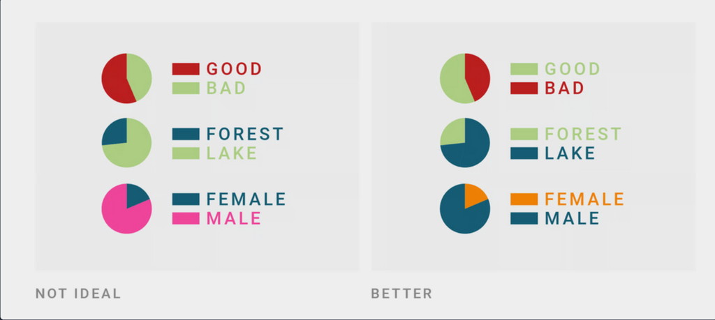

[Blogpost on colours by Lisa Charlotte Muth (Datawrapper)](https://www.datawrapper.de/blog/colors)

## Two things that matter

For scientific figures:

1. **Intuitive** colours that match what your reader expects
2. **Colourblind-safe** colours

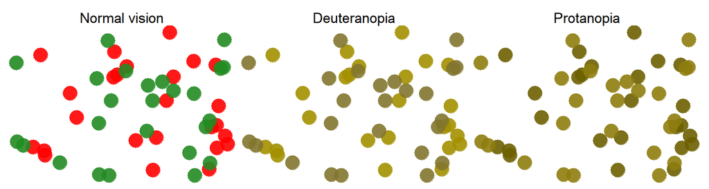

## Three kinds of palettes

**Qualitative**

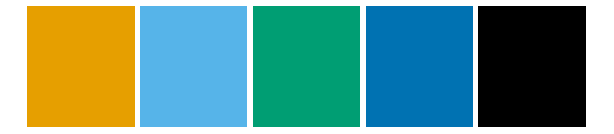

Distinct categories

**Sequential**

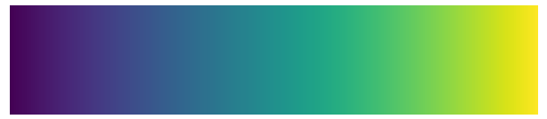

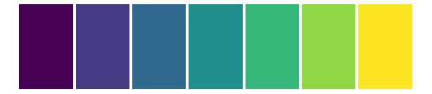

Ordered, low to high

**Diverging**

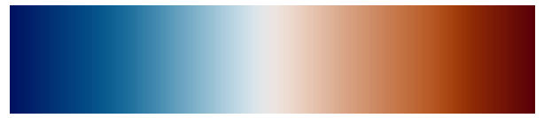

Above / below a midpoint

## Okabe-Ito (base R)

A colourblind-safe qualitative palette, built into base R.

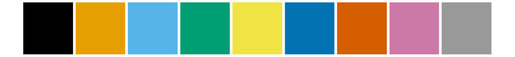

[See here for details](https://clauswilke.com/dataviz/color-pitfalls.html#fig:palette-Okabe-Ito)

## viridis (built into ggplot2)

Perceptually uniform, colourblind- and greyscale-safe. Best for ordered or continuous data.

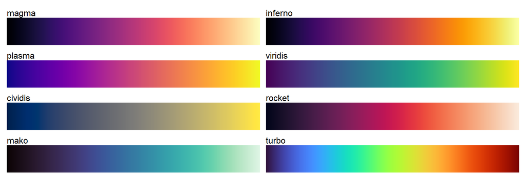

- access with `scale_colour_viridis_d()` / `_c()`

[See here for details](https://ggplot2.tidyverse.org/reference/scale_viridis.html)

## scico R package

Perceptually uniform and colourblind-safe. Made for **scientific data** and designed to be fair, readable, and citable

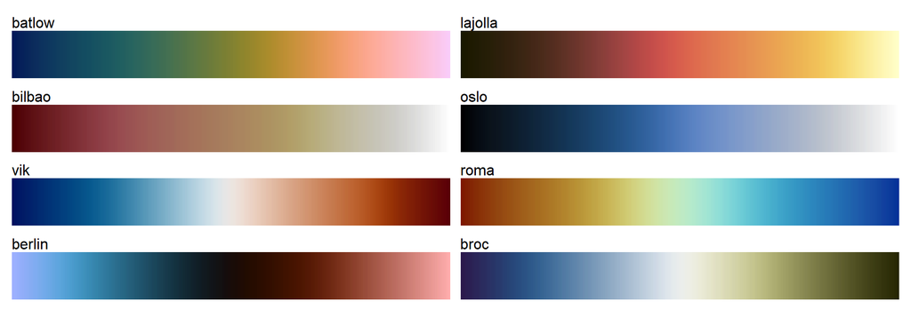

- access with `scale_colour_scico_d()` / `_c()`

[scico R package](https://github.com/thomasp85/scico), the [colour maps by Fabio Crameri](https://www.fabiocrameri.ch/colourmaps/)

## Live demo

Open `demo/02_color.R`.

## Your turn

> ✏️ **Exercise (~5 min):**

> Open `exercises/02_color_exercise.R`

# 3. Multi-panel layouts

## Common multi-panel layouts

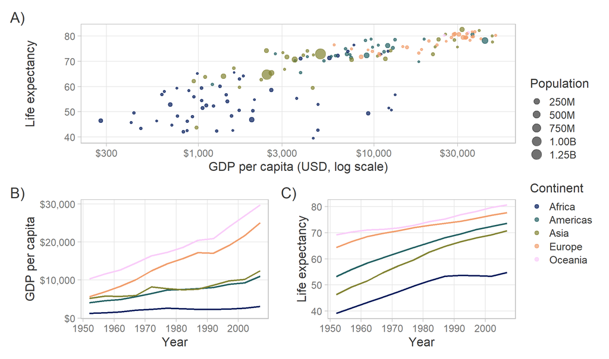

## The patchwork package

- Compose plots
- Collect shared legends and axes
- Tag panels
- Apply additional plot layers to every panel
- Place plots inside plots as insets

The [patchwork documentation](https://patchwork.data-imaginist.com/) is excellent

## Live demo

Open `demo/03_patchwork.R`.

## Your turn

> ✏️ **Exercise (~8 min):**

> Open `exercises/03_patchwork_exercise.R`

# 4. Exporting figures

## Same plot, different canvas

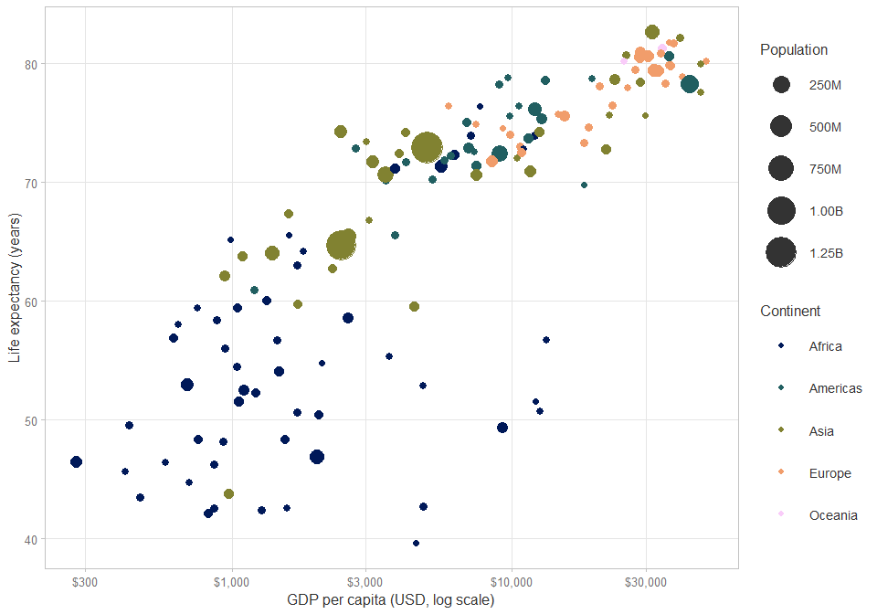

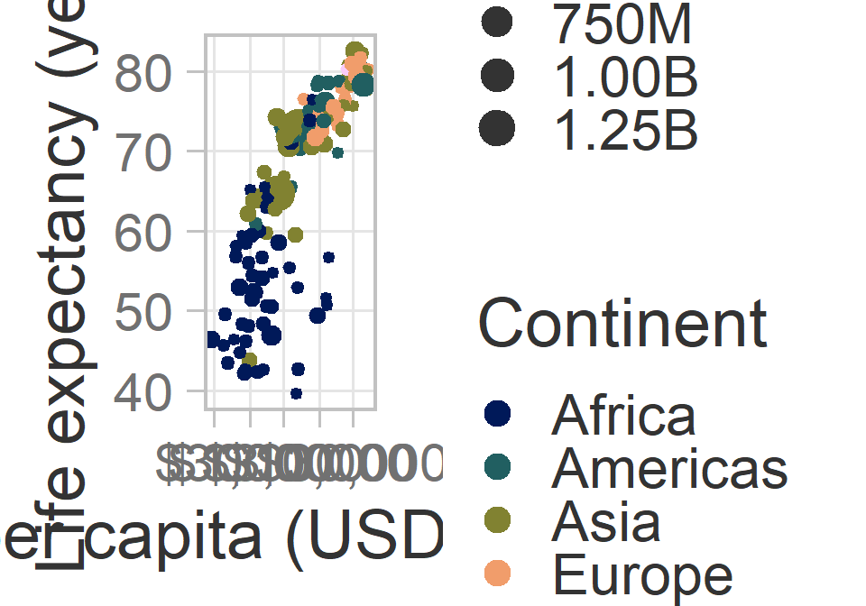

## Rule of thumb

Starting points for Canvas and font sizes:

| Outlet | Canvas width | `base_size` |
| --- | --- | --- |
| Paper, single column | ~89 mm | 8–10 |
| Paper, double column | ~120–180 mm | 10–12 |
| Slide, half | ~150 mm | 14–16 |
| Slide, full | ~250 mm | 18–22 |
| Poster | depends on layout | 18–24 |

## Live demo

Open `demo/04_export.R`.

## Your turn

> ✏️ **Exercise (~7 min):**

> Open `exercises/04_export_exercise.R`

# Other handy packages

The official [ggplot extension gallery](https://exts.ggplot2.tidyverse.org/gallery/) lists ~120 community extension packages to browse

## `gghighlight`

[`gghighlight`](https://yutannihilation.github.io/gghighlight/) to fade data and highlight specific elements.

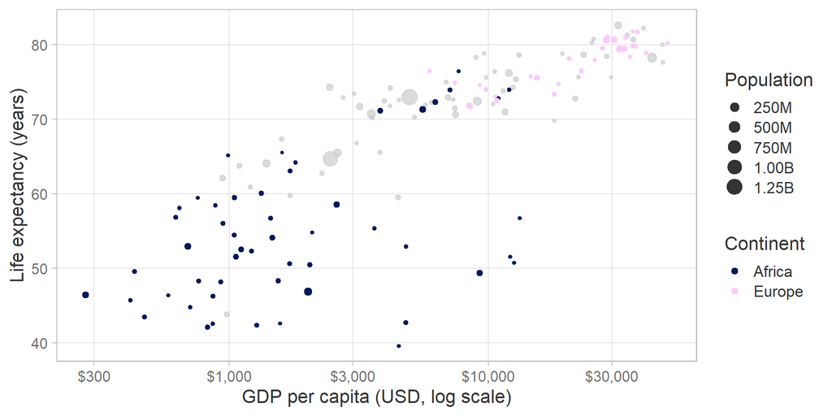

```r
library(gghighlight)
p_bubble +
  scale_color_scico_d(palette = "batlow") +
  theme_workshop() +
  gghighlight(
    continent %in% c("Europe", "Africa"),
    use_direct_label = FALSE
  )
```

## `ggrepel` + `ggtext`

[`ggrepel`](https://ggrepel.slowkow.com/) and [`ggtext`](https://wilkelab.org/ggtext/) for labels and markdown text

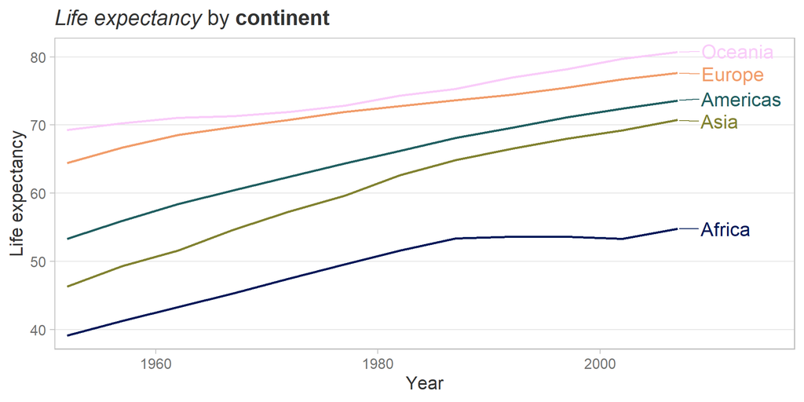

```r
library(ggrepel)
library(ggtext)
ggplot(gap_continent, aes(year, mean_lifeExp, color = continent)) +
  geom_line(linewidth = 1) +
  geom_text_repel(
    data = gap_continent |> filter(year == max(year)),
    aes(label = continent),
    size = 6,
    nudge_x = 2,
    hjust = 0,
    direction = "y",
    seed = 1
  ) +
  scale_x_continuous(expand = expansion(mult = c(0.02, 0.15))) +
  scale_color_scico_d(palette = "batlow") +
  # use markdown in the title (see theme layer)
  labs(
    title = "*Life expectancy* by **continent**",
    x = "Year",
    y = "Life expectancy"
  ) +
  theme_workshop() +
  theme(
    panel.grid.major.x = element_blank(),
    plot.title = element_markdown(),
    legend.position = "none"
  )
```

## `ggdist` raincloud plots

[`ggdist`](https://mjskay.github.io/ggdist/) to show distributions and uncertainty -> Barplot alternatives

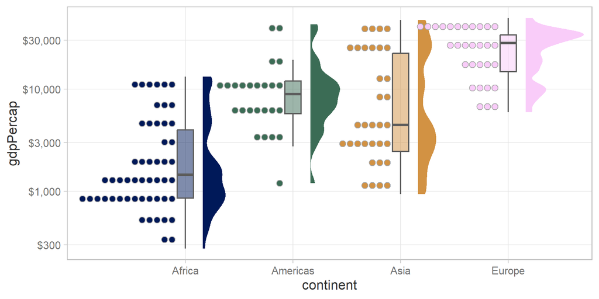

```r
library(ggdist)
ggplot(
  gap_2007 |> filter(continent != "Oceania"),
  aes(continent, gdpPercap, fill = continent)
) +
  stat_halfeye(
    adjust = 0.5,
    width = 0.6,
    .width = 0,
    justification = -0.3,
    point_colour = NA
  ) +
  geom_boxplot(width = 0.15, outlier.shape = NA, alpha = 0.5) +
  stat_dots(side = "left", justification = 1.1, dotsize = 0.4) +
  scale_y_log10(labels = label_dollar(accuracy = 1)) +
  scale_fill_scico_d(palette = "batlow") +
  theme_workshop() +
  theme(legend.position = "none")
```

## `ggridges`

[`ggridges`](https://wilkelab.org/ggridges/) for ridgeline distribution plots

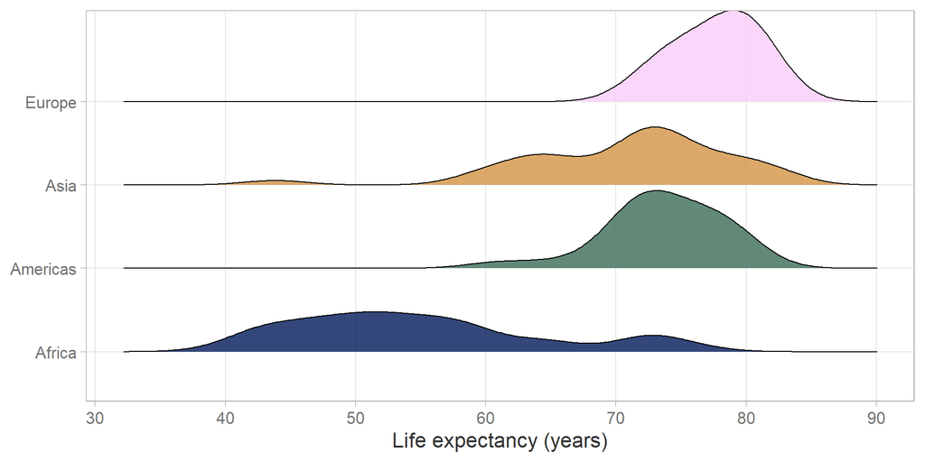

```r
library(ggridges)
ggplot(gap_2007 |> filter(continent != "Oceania"), aes(lifeExp, continent, fill = continent)) +
  geom_density_ridges(alpha = 0.8, scale = 1.1) +
  scale_fill_scico_d(palette = "batlow") +
  theme_workshop() +
  theme(legend.position = "none") +
  labs(x = "Life expectancy (years)", y = NULL)
```

## Takeaways

What you can take back to your own plots:

1. **Custom themes**: write one `theme_*()` function, source it, `theme_set()` it everywhere it’s needed
2. **Colour with intent**: pick intuitive, colourblind-safe palettes (Okabe-Ito, viridis, scico), and check with `cvdPlot()`
3. **Multi-panel layouts**: compose plots with `patchwork`, collect shared legends, add tag panels, …
4. **Export**: pick the canvas size, preview with `ggview::canvas()`, tweak `base_size` and geoms, and save with `ragg::ragg_png` or `cairo_pdf`.

## Next lecture/workshop

#### Topic tba

📅 18.06.2026 🕓 4-5 p.m. 📍 Webex

🔔 [Subscribe to the mailing list](https://lists.fu-berlin.de/listinfo/toolsAndTips)

📧 For topic suggestions and/or feedback send me an email

# The end :)

Questions?